# Snack Market Gap Analysis

## Business Objective

The goal of this project is to identify underserved opportunities in the snack market using nutritional data from OpenFoodFacts.

Rather than simply describing existing products, the project aims to answer:

> If a company wanted to launch a new snack product today, what nutritional profile would offer the strongest opportunity?

The analysis combines:

- Data engineering
- Feature engineering
- Market segmentation
- Nutritional intelligence
- Unsupervised machine learning

Dataset: OpenFoodFacts Product Database

```python
import pandas as pd
import numpy as np
from pathlib import Path
```

```python
# I worked in google colab

DATA_PATH = "https://static.openfoodfacts.org/data/en.openfoodfacts.org.products.csv.gz"
```

## Phase 1 — Data Ingestion

The OpenFoodFacts database contains millions of products.

To efficiently process the dataset:

- Only required columns were loaded
- Data was streamed in chunks
- Snack-related products were filtered early

This reduced memory consumption while focusing the analysis on relevant products.

```python
USE_COLS = [
    "product_name",
    "categories",
    "ingredients_text",
    "energy-kcal_100g",
    "proteins_100g",
    "fat_100g",
    "fiber_100g",
    "sugars_100g"
]
```

```python
SNACK_KEYWORDS = [
    "snack",
    "chips",
    "crisps",
    "cracker",
    "cookie",
    "biscuit",
    "popcorn",
    "bar",
    "pretzel",
    "nuts"
]


def is_snack(category_text):
    if pd.isna(category_text):
        return False

    text = str(category_text).lower()

    return any(keyword in text for keyword in SNACK_KEYWORDS)
```

```python
chunks = []

for chunk in pd.read_csv(
    DATA_PATH,
    sep="\t",
    compression="gzip",
    usecols=USE_COLS,
    chunksize=50000,
    low_memory=False
):

    snack_chunk = chunk[
        chunk["categories"].apply(is_snack)
    ]

    chunks.append(snack_chunk)

snacks_df = pd.concat(chunks, ignore_index=True)
```

```python
print(f"Rows: {len(snacks_df):,}")
print(f"Columns: {snacks_df.shape[1]}")

snacks_df.head()
```

```
Rows: 330,506
Columns: 8
```

|  | product_name | categories | ingredients_text | energy-kcal_100g | fat_100g | sugars_100g | fiber_100g | proteins_100g |
| --- | --- | --- | --- | --- | --- | --- | --- | --- |
| 0 | xxx | Beverages and beverages preparations, Beverage... | Farine de blé 33%, sucre, huile de colza, œufs... | NaN | NaN | NaN | NaN | NaN |
| 1 | Powdered peanut butter | Snacks, Meals, Rice dishes, Risottos, Powder p... | Water, Leptospermum Scoparium Mel (Manuka Hone... | NaN | NaN | NaN | NaN | NaN |
| 2 | Madeleines ChocoLait | Snacks, Snacks sucrés, Biscuits et gâteaux, Gâ... | Farine de blé 27%, chocolat au lait 18% (sucre... | NaN | NaN | NaN | NaN | NaN |
| 3 | Nesquik moins de sucre | Snacks, Snacks sucrés, Biscuits et gâteaux, Gâ... | Nuts (Peanuts, Almonds), Prebiotic Blend (Tapi... | NaN | NaN | NaN | NaN | NaN |
| 4 | Farandole de madeleine | Snacks, Snacks sucrés, Biscuits et gâteaux, Gâ... | Madeleines ChocoNoir - Madeleines nappées de c... | NaN | NaN | NaN | NaN | NaN |

```python
OUTPUT_DIR = Path("data")
OUTPUT_DIR.mkdir(exist_ok=True)

snacks_df.to_csv(
    OUTPUT_DIR / "snacks_raw.csv",
    index=False
)

print("Saved snacks_raw.csv")
```

```
Saved snacks_raw.csv
```

## Phase 2 — Data Cleaning

Nutritional datasets frequently contain missing values and data-entry errors.

Cleaning steps:

- Removed products missing key nutritional information
- Imputed missing fiber values using the median
- Removed impossible nutritional values

The objective was to create a reliable analytical dataset before feature engineering.

```python
nutrition_cols = [
    "energy-kcal_100g",
    "fat_100g",
    "sugars_100g",
    "fiber_100g",
    "proteins_100g"
]

snacks_df[nutrition_cols].isna().mean()*100
```

|  | 0 |
| --- | --- |
| energy-kcal_100g | 41.738123 |
| fat_100g | 41.888498 |
| sugars_100g | 42.302409 |
| fiber_100g | 65.316817 |
| proteins_100g | 41.868831 |

**dtype:** float64

```python
core_cols = [
    "energy-kcal_100g",
    "proteins_100g",
    "sugars_100g",
    "fat_100g"
]

clean_df = snacks_df.dropna(subset=core_cols)

print(len(snacks_df))
print(len(clean_df))
```

```
330506
190171
```

```python
snacks_df["categories"].sample(20, random_state=42).tolist()
```

```
['Snacks,Sweet snacks,Bars,Cereal bars,Dietary supplements,Bodybuilding supplements,Energy bars,Protein bars,Protein Energy Bars',
 'en:barbecue-sauces',
 'Snacks, Sweet snacks, Confectioneries, Candies',
 'Snacks, Sweet snacks, Biscuits and cakes, Biscuits',
 'en:crisps',
 'Snacks, Snacks sucrés, Cacao et dérivés, Chocolats, Chocolats au lait, en:salted-caramel-milk-chocolate',
 'Snacks, Sweet snacks, Cocoa and its products, Confectioneries, Chocolate candies, en:chocolates',
 'Snacks',
 'Snacks, Sweet snacks, Cocoa and its products, Confectioneries, Chocolate candies, Bonbons',
 'Snacks',
 'snacks, snacks-sucrés, cacao-et-dérivés, confiseries, confiseries-chocolatées, bonbons-de-chocolat, bonbons, fr:confiseries, en:snacks-sucrés',
 'Snacks, Sweet snacks, Biscuits and cakes, Biscuits, Chocolate biscuits, Drop cookies, Chocolate chip cookies',
 'Botanas,Snacks dulces,Dulces',
 'Snacks, Sweet snacks, Bars, Cereal bars, Chocolate cereal bars, en:protein-bars',
 'Snacks',
 'Snacks, Snacks sucrés, Cacao et dérivés, Confiseries, Confiseries chocolatées, Bonbons de chocolat, Assortiments de bonbons de chocolat, Papillotes en chocolat',
 'Snacks, Sweet snacks, Cocoa and its products, Confectioneries, Chocolate candies',
 'en:nuts',
 'Snacks',
 'Snacks, Sweet snacks, Confectioneries, Caramels, en:candies']
```

```python
clean_df["fiber_100g"] = (
    clean_df["fiber_100g"]
    .fillna(clean_df["fiber_100g"].median())
)
```

```python
print(f"Rows: {len(clean_df):,}")
print(f"Columns: {clean_df.shape[1]}")

clean_df.head()
```

```
Rows: 190,171
Columns: 8
```

|  | product_name | categories | ingredients_text | energy-kcal_100g | fat_100g | sugars_100g | fiber_100g | proteins_100g |
| --- | --- | --- | --- | --- | --- | --- | --- | --- |
| 34 | Donut Milka | Snacks, Snacks sucrés, Biscuits et gâteaux, Gâ... | NaN | 465.0 | 28.0 | 18.0 | 3.1 | 6.0 |
| 37 | Cigarettes Fourrées Chocolat Noisettes | Snacks, Sweet snacks, Biscuits and cakes, Bisc... | Fourrage chocolat noisette 55% (chocolat en po... | 488.0 | 21.0 | 48.0 | 3.5 | 6.0 |
| 43 | 8 mini beignets fourrés au chocolat noisette | Snacks, Snacks sucrés, Beignets sucrés, Beigne... | NaN | 428.0 | 24.0 | 19.0 | 3.1 | 6.8 |
| 44 | Food Grade Corn | Snacks, Sweet snacks, Biscuits and cakes, Bisc... | Farine de _blé_, sucre, _beurre_ concentré (so... | 505.0 | 26.0 | 33.0 | 3.3 | 7.0 |
| 46 | Pain au chocolat pur beurre x10 | Snacks, Snacks sucrés, Viennoiseries, Pains au... | NaN | 422.0 | 23.7 | 10.0 | 3.1 | 7.3 |

## Phase 3 — Category Engineering

OpenFoodFacts contains thousands of detailed category labels.

To improve interpretability, products were grouped into high-level snack categories:

- Protein Bars
- Nuts
- Cookies
- Chips
- Candy & Chocolate
- Crackers
- Popcorn
- Pretzels
- Other Snacks

This creates business-friendly market segments.

```python
def assign_category(text):

    if pd.isna(text):
        return "other_snacks"

    text = text.lower()

    if "protein bar" in text:
        return "protein_bars"

    elif "cookie" in text or "biscuit" in text:
        return "cookies"

    elif "chips" in text or "crisps" in text:
        return "chips"

    elif "cracker" in text:
        return "crackers"

    elif "popcorn" in text:
        return "popcorn"

    elif "pretzel" in text:
        return "pretzels"

    elif "nuts" in text:
        return "nuts"

    elif (
        "chocolate" in text
        or "candy" in text
        or "confectionery" in text
        or "caramel" in text
    ):
        return "candy_chocolate"

    return "other_snacks"
```

```python
clean_df["snack_category"] = (
    clean_df["categories"]
    .apply(assign_category)
)
```

```python
print(f"Rows: {len(clean_df):,}")
print(f"Columns: {clean_df.shape[1]}")

clean_df.head(100)
```

```
Rows: 190,171
Columns: 9
```

|  | product_name | categories | ingredients_text | energy-kcal_100g | fat_100g | sugars_100g | fiber_100g | proteins_100g | snack_category |
| --- | --- | --- | --- | --- | --- | --- | --- | --- | --- |
| 34 | Donut Milka | Snacks, Snacks sucrés, Biscuits et gâteaux, Gâ... | NaN | 465.0 | 28.0 | 18.0 | 3.1 | 6.0 | cookies |
| 37 | Cigarettes Fourrées Chocolat Noisettes | Snacks, Sweet snacks, Biscuits and cakes, Bisc... | Fourrage chocolat noisette 55% (chocolat en po... | 488.0 | 21.0 | 48.0 | 3.5 | 6.0 | cookies |
| 43 | 8 mini beignets fourrés au chocolat noisette | Snacks, Snacks sucrés, Beignets sucrés, Beigne... | NaN | 428.0 | 24.0 | 19.0 | 3.1 | 6.8 | other_snacks |
| 44 | Food Grade Corn | Snacks, Sweet snacks, Biscuits and cakes, Bisc... | Farine de _blé_, sucre, _beurre_ concentré (so... | 505.0 | 26.0 | 33.0 | 3.3 | 7.0 | cookies |
| 46 | Pain au chocolat pur beurre x10 | Snacks, Snacks sucrés, Viennoiseries, Pains au... | NaN | 422.0 | 23.7 | 10.0 | 3.1 | 7.3 | other_snacks |
| ... | ... | ... | ... | ... | ... | ... | ... | ... | ... |
| 295 | 4 beignets à la pomme | Snacks, Snacks sucrés, Beignets sucrés, Beigne... | NaN | 310.0 | 9.6 | 20.0 | 3.1 | 6.6 | other_snacks |
| 296 | Pasta di cacao nero assoluto 100% | Snack, Snack dolci, Cacao e i suoi derivati, C... | NaN | 623.0 | 54.0 | 0.5 | 3.1 | 14.0 | other_snacks |
| 297 | Cioccolato fondente mirtillo e ibisco 54% | Snack, Snack dolci, Cacao e i suoi derivati, C... | NaN | 457.0 | 32.4 | 6.5 | 3.1 | 5.0 | other_snacks |
| 303 | Choco Changer Salted Caramel | Snacks, Sweet snacks, Cocoa and its products, ... | NaN | 537.0 | 30.0 | 58.0 | 3.1 | 6.5 | candy_chocolate |
| 304 | Naranjitos | Botanas, Snacks dulces, Cacao y sus productos,... | NaN | 412.0 | 16.7 | 56.6 | 3.1 | 3.0 | candy_chocolate |

100 rows × 9 columns

```python
clean_df["snack_category"].value_counts()
```

| snack_category | count |
| --- | --- |
| other_snacks | 92434 |
| cookies | 51857 |
| chips | 15805 |
| candy_chocolate | 15153 |
| nuts | 9253 |
| crackers | 2521 |
| popcorn | 1530 |
| protein_bars | 1461 |
| pretzels | 157 |

**dtype:** int64

```python
nutrition_cols = [
    "energy-kcal_100g",
    "fat_100g",
    "sugars_100g",
    "fiber_100g",
    "proteins_100g"
]

clean_df[nutrition_cols].isna().mean() * 100
```

|  | 0 |
| --- | --- |
| energy-kcal_100g | 0.0 |
| fat_100g | 0.0 |
| sugars_100g | 0.0 |
| fiber_100g | 0.0 |
| proteins_100g | 0.0 |

**dtype:** float64

## Phase 4 — Health Score Feature

A custom health score was created:

Health Score = Protein + Fiber − Sugar

This simple metric rewards desirable nutrients while penalizing excessive sugar.

The score provides an intuitive way to compare products and categories.

```python
clean_df["health_score"] = (
    clean_df["proteins_100g"]
    + clean_df["fiber_100g"]
    - clean_df["sugars_100g"]
)
```

```python
clean_df["health_score"].describe()
```

|  | health_score |
| --- | --- |
| count | 190171.000000 |
| mean | -15.824236 |
| std | 172.109303 |
| min | -73997.200000 |
| 25% | -32.300000 |
| 50% | -15.500000 |
| 75% | 4.000000 |
| max | 5602.000000 |

**dtype:** float64

```python
nutrient_matrix = clean_df[
    [
        "product_name",
        "snack_category",
        "sugars_100g",
        "proteins_100g",
        "health_score"
    ]
].copy()
```

```python
nutrient_matrix.head()
```

|  | product_name | snack_category | sugars_100g | proteins_100g | health_score |
| --- | --- | --- | --- | --- | --- |
| 34 | Donut Milka | cookies | 18.0 | 6.0 | -8.9 |
| 37 | Cigarettes Fourrées Chocolat Noisettes | cookies | 48.0 | 6.0 | -38.5 |
| 43 | 8 mini beignets fourrés au chocolat noisette | other_snacks | 19.0 | 6.8 | -9.1 |
| 44 | Food Grade Corn | cookies | 33.0 | 7.0 | -22.7 |
| 46 | Pain au chocolat pur beurre x10 | other_snacks | 10.0 | 7.3 | 0.4 |

```python
category_summary = (
    clean_df
    .groupby("snack_category")
    .agg({
        "proteins_100g":"mean",
        "sugars_100g":"mean",
        "fiber_100g":"mean",
        "health_score":"mean"
    })
    .round(2)
)

category_summary
```

| snack_category | proteins_100g | sugars_100g | fiber_100g | health_score |
| --- | --- | --- | --- | --- |
| candy_chocolate | 6.33 | 40.86 | 3.93 | -30.59 |
| chips | 6.57 | 3.48 | 4.04 | 7.13 |
| cookies | 6.64 | 27.35 | 3.24 | -17.47 |
| crackers | 10.17 | 4.52 | 4.45 | 10.09 |
| nuts | 16.02 | 14.44 | 6.04 | 7.62 |
| other_snacks | 7.37 | 31.53 | 3.81 | -20.35 |
| popcorn | 7.10 | 16.93 | 6.71 | -3.12 |
| pretzels | 9.97 | 6.36 | 3.78 | 7.39 |
| protein_bars | 28.89 | 12.53 | 8.39 | 24.74 |

```python
nutrition_cols = [
    "energy-kcal_100g",
    "fat_100g",
    "sugars_100g",
    "fiber_100g",
    "proteins_100g"
]

for col in nutrition_cols:
    clean_df[col] = pd.to_numeric(
        clean_df[col],
        errors="coerce"
    )
```

```python
clean_df = clean_df.dropna(
    subset=[
        "energy-kcal_100g",
        "proteins_100g",
        "sugars_100g",
        "fat_100g",
        "fiber_100g"
    ]
)
```

```python
clean_df = clean_df[

    (clean_df["energy-kcal_100g"].between(0, 900)) &
    (clean_df["proteins_100g"].between(0, 100)) &
    (clean_df["sugars_100g"].between(0, 100)) &
    (clean_df["fat_100g"].between(0, 100)) &
    (clean_df["fiber_100g"].between(0, 100))
].copy()
```

```python
print(len(clean_df))
```

```
189726
```

```python
clean_df["health_score"] = (
    clean_df["proteins_100g"]
    + clean_df["fiber_100g"]
    - clean_df["sugars_100g"]
)

clean_df["health_score"].describe()
```

|  | health_score |
| --- | --- |
| count | 189726.000000 |
| mean | -15.470637 |
| std | 24.839588 |
| min | -100.000000 |
| 25% | -32.300000 |
| 50% | -15.500000 |
| 75% | 4.000000 |
| max | 156.000000 |

**dtype:** float64

```python
plot_df = clean_df.sample(
    n=10000,
    random_state=42
)
```

```python
median_sugar = clean_df["sugars_100g"].median()
median_protein = clean_df["proteins_100g"].median()

print(median_sugar)
print(median_protein)
```

```
26.0
6.4
```

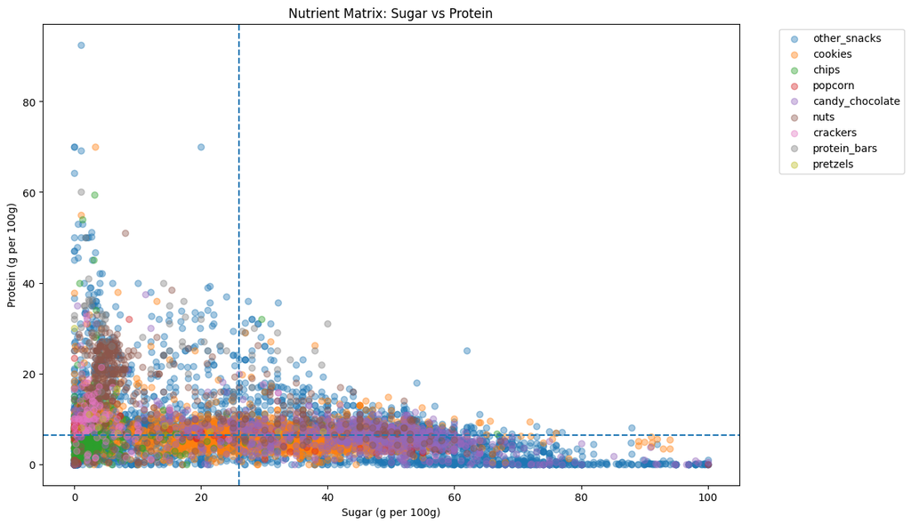

```python
import matplotlib.pyplot as plt

plt.figure(figsize=(12,8))

for category in plot_df["snack_category"].unique():

    subset = plot_df[
        plot_df["snack_category"] == category
    ]

    plt.scatter(
        subset["sugars_100g"],
        subset["proteins_100g"],
        alpha=0.4,
        label=category
    )

plt.axvline(
    26.0,
    linestyle="--"
)

plt.axhline(
    6.4,
    linestyle="--"
)

plt.xlabel("Sugar (g per 100g)")
plt.ylabel("Protein (g per 100g)")
plt.title("Nutrient Matrix: Sugar vs Protein")

plt.legend(
    bbox_to_anchor=(1.05,1),
    loc="upper left"
)

plt.show()
```

```python
opportunity_df = clean_df[
    (clean_df["proteins_100g"] > 6.4) &
    (clean_df["sugars_100g"] < 26.0)
]
```

```python
len(opportunity_df)
```

```
56800
```

```python
100 * len(opportunity_df) / len(clean_df)
```

```
29.937910460348082
```

```python
(
    opportunity_df["snack_category"]
    .value_counts()
    .head(10)
)
```

| snack_category | count |
| --- | --- |
| other_snacks | 26088 |
| cookies | 12009 |
| nuts | 6531 |
| chips | 6074 |
| crackers | 2131 |
| candy_chocolate | 1794 |
| protein_bars | 1196 |
| popcorn | 845 |
| pretzels | 132 |

**dtype:** int64

## Phase 5 — Nutrient Opportunity Analysis

The core business question is:

> Where are products concentrated, and where are opportunities underrepresented?

Products were visualized using:

- Sugar (X-axis)
- Protein (Y-axis)

Quadrants were used to identify potential opportunity zones, particularly:

- High Protein
- Low Sugar

```python
import numpy as np

nos_df = (
    clean_df
    .groupby("snack_category")
    .agg(
        product_count=("product_name", "count"),
        mean_protein=("proteins_100g", "mean"),
        mean_fiber=("fiber_100g", "mean"),
        mean_sugar=("sugars_100g", "mean")
    )
)

nos_df["NOS"] = (
    nos_df["mean_protein"]
    + nos_df["mean_fiber"]
    - nos_df["mean_sugar"]
) / np.log1p(
    nos_df["product_count"]
)

nos_df = nos_df.sort_values(
    "NOS",
    ascending=False
)

nos_df
```

| snack_category | product_count | mean_protein | mean_fiber | mean_sugar | NOS |
| --- | --- | --- | --- | --- | --- |
| protein_bars | 1388 | 28.693201 | 8.387256 | 12.547789 | 3.390204 |
| pretzels | 155 | 9.967249 | 3.783722 | 6.361876 | 1.463229 |
| crackers | 2438 | 10.158954 | 4.447430 | 4.518401 | 1.293440 |
| nuts | 8917 | 15.899840 | 6.025479 | 14.319633 | 0.836173 |
| chips | 15272 | 6.530784 | 4.018823 | 3.481242 | 0.733702 |
| popcorn | 1481 | 7.028829 | 6.622308 | 17.022154 | -0.461711 |
| cookies | 50816 | 6.587076 | 3.216145 | 27.329076 | -1.617375 |
| other_snacks | 90623 | 7.341601 | 3.741007 | 30.666817 | -1.715735 |
| candy_chocolate | 14678 | 6.322704 | 3.935741 | 40.776728 | -3.180919 |

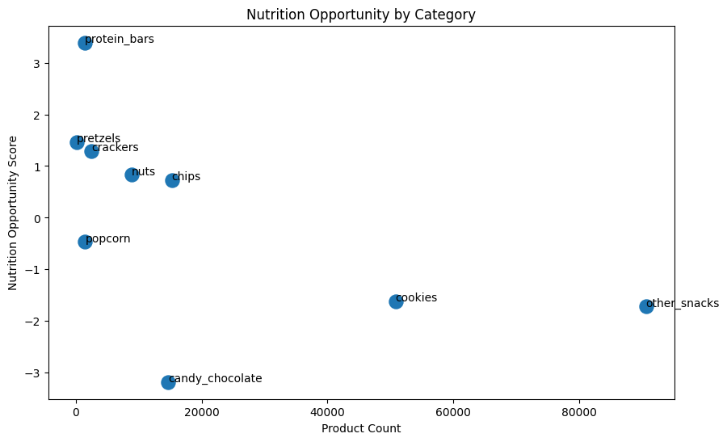

```python
plt.figure(figsize=(10,6))

plt.scatter(
    nos_df["product_count"],
    nos_df["NOS"],
    s=150
)

for category in nos_df.index:
    plt.annotate(
        category,
        (
            nos_df.loc[category, "product_count"],
            nos_df.loc[category, "NOS"]
        )
    )

plt.xlabel("Product Count")
plt.ylabel("Nutrition Opportunity Score")
plt.title("Nutrition Opportunity by Category")

plt.show()
```

## Candidate's Choice Feature: Nutrition Opportunity Score (NOS)

The project requirements asked for identifying market opportunities through visualization.

However, visual inspection alone does not quantify opportunity.

To address this limitation, a custom Nutrition Opportunity Score (NOS) was developed.

NOS combines:

- Protein content
- Fiber content
- Sugar content
- Category saturation

into a single metric.

This allows categories to be ranked according to both nutritional attractiveness and competitive density.

The score provides a quantitative framework for identifying potentially underserved product segments.

## Phase 7 — Ingredient Intelligence

Products within the High Protein / Low Sugar opportunity zone were analyzed.

Ingredient frequency analysis was performed to identify common protein sources used by successful products.

This provides actionable insights for product development teams.

```python
high_protein_low_sugar = clean_df[
    (clean_df["proteins_100g"] > 6.4) &
    (clean_df["sugars_100g"] < 26)
].copy()
```

```python
 len(high_protein_low_sugar)
```

```
56800
```

```python
ingredient_text = " ".join(
    high_protein_low_sugar["ingredients_text"]
    .fillna("")
    .astype(str)
)
```

```python
protein_sources = [
    "whey",
    "milk protein",
    "soy",
    "soy protein",
    "pea protein",
    "peanut",
    "peanuts",
    "almond",
    "almonds",
    "cashew",
    "cashews",
    "egg",
    "eggs",
    "oats",
    "oat protein"
]
```

```python
from collections import Counter

counts = {}

text = ingredient_text.lower()

for ingredient in protein_sources:
    counts[ingredient] = text.count(ingredient)

protein_counts = (
    pd.Series(counts)
    .sort_values(ascending=False)
)

protein_counts.head(10)
```

|  | 0 |
| --- | --- |
| soy | 7382 |
| peanut | 3631 |
| peanuts | 2379 |
| whey | 2349 |
| almond | 1930 |
| egg | 1523 |
| almonds | 1467 |
| cashew | 1304 |
| oats | 988 |
| soy protein | 831 |

**dtype:** int64

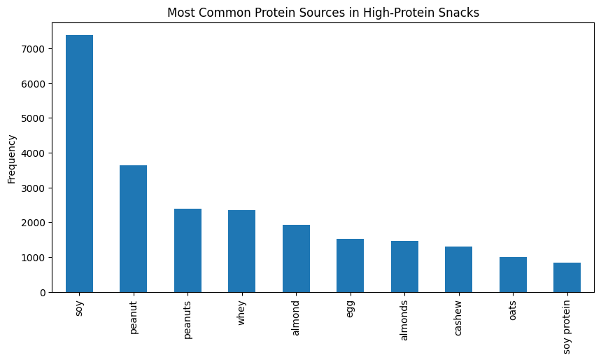

```python
protein_counts.head(10).plot(
    kind="bar",
    figsize=(10,5)
)

plt.title(
    "Most Common Protein Sources in High-Protein Snacks"
)

plt.ylabel("Frequency")

plt.show()
```

## — Ingredient Intelligence

Analysis of products located in the High Protein + Low Sugar opportunity region revealed several recurring protein sources.

The most common ingredients were soy, peanuts, whey, almonds, eggs, and cashews. These ingredients appear repeatedly across nutritionally attractive products and therefore represent key formulation strategies used by existing manufacturers.

The results suggest that successful high-protein snacks rely on a combination of traditional protein fortification ingredients (soy, whey) and whole-food protein sources (nuts, oats, eggs). This insight can guide future product development by identifying ingredients that already demonstrate market acceptance.

## Phase 8 — K-Means Market Segmentation

K-Means clustering was used to identify naturally occurring nutritional segments.

Features used:

- Energy
- Fat
- Sugar
- Fiber
- Protein

Cluster selection was based on:

- Elbow Method
- Silhouette Analysis

```python
cluster_features = [
    "energy-kcal_100g",
    "fat_100g",
    "sugars_100g",
    "fiber_100g",
    "proteins_100g"
]
```

```python
X = clean_df[cluster_features]
```

```python
from sklearn.preprocessing import StandardScaler

scaler = StandardScaler()

X_scaled = scaler.fit_transform(X)
```

```python
X_scaled.shape
```

```
(189726, 5)
```

```python
clean_df[cluster_features].isna().mean() * 100
```

|  | 0 |
| --- | --- |
| energy-kcal_100g | 0.0 |
| fat_100g | 0.0 |
| sugars_100g | 0.0 |
| fiber_100g | 0.0 |
| proteins_100g | 0.0 |

**dtype:** float64

```python
cluster_df[cluster_features].head(100)
```

|  | energy-kcal_100g | fat_100g | sugars_100g | fiber_100g | proteins_100g |
| --- | --- | --- | --- | --- | --- |
| 34 | 465.0 | 28.0 | 18.0 | 3.1 | 6.0 |
| 37 | 488.0 | 21.0 | 48.0 | 3.5 | 6.0 |
| 43 | 428.0 | 24.0 | 19.0 | 3.1 | 6.8 |
| 44 | 505.0 | 26.0 | 33.0 | 3.3 | 7.0 |
| 46 | 422.0 | 23.7 | 10.0 | 3.1 | 7.3 |
| ... | ... | ... | ... | ... | ... |
| 295 | 310.0 | 9.6 | 20.0 | 3.1 | 6.6 |
| 296 | 623.0 | 54.0 | 0.5 | 3.1 | 14.0 |
| 297 | 457.0 | 32.4 | 6.5 | 3.1 | 5.0 |
| 303 | 537.0 | 30.0 | 58.0 | 3.1 | 6.5 |
| 304 | 412.0 | 16.7 | 56.6 | 3.1 | 3.0 |

100 rows × 5 columns

```python
X = cluster_df[cluster_features]

scaler = StandardScaler()
X_scaled = scaler.fit_transform(X)
```

```python
import numpy as np

sample_size = 10000

np.random.seed(42)

sample_idx = np.random.choice(
    len(X_scaled),
    size=sample_size,
    replace=False
)

X_sample = X_scaled[sample_idx]

print(X_sample.shape)
```

```
(10000, 5)
```

```python
from sklearn.cluster import KMeans

inertia = []

for k in range(2,11):

    kmeans = KMeans(
        n_clusters=k,
        random_state=42,
        n_init=10
    )

    kmeans.fit(X_sample)

    inertia.append(kmeans.inertia_)
```

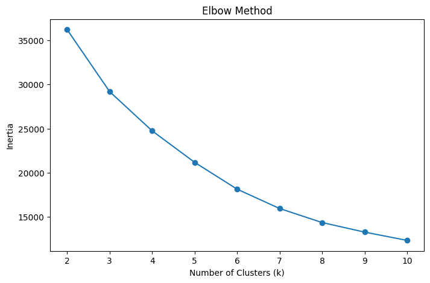

```python
plt.figure(figsize=(8,5))

plt.plot(
    range(2,11),
    inertia,
    marker="o"
)

plt.xlabel("Number of Clusters (k)")
plt.ylabel("Inertia")
plt.title("Elbow Method")

plt.show()
```

```python
#justifying choice of k
```

```python
from sklearn.metrics import silhouette_score

scores = []

for k in range(2,11):

    kmeans = KMeans(
        n_clusters=k,
        random_state=42,
        n_init=10
    )

    labels = kmeans.fit_predict(X_sample)

    score = silhouette_score(
        X_sample,
        labels
    )

    scores.append(score)
```

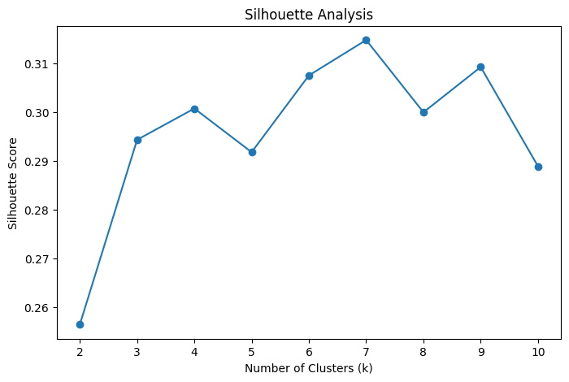

```python
plt.figure(figsize=(8,5))

plt.plot(
    range(2,11),
    scores,
    marker="o"
)

plt.xlabel("Number of Clusters (k)")
plt.ylabel("Silhouette Score")
plt.title("Silhouette Analysis")

plt.show()
```

```python
for k, score in zip(range(2,11), scores):
    print(f"k={k}: {score:.4f}")
```

```
k=2: 0.2564
k=3: 0.2943
k=4: 0.3007
k=5: 0.2917
k=6: 0.3075
k=7: 0.3147
k=8: 0.2999
k=9: 0.3092
k=10: 0.2888
```

```python
kmeans = KMeans(
    n_clusters=4,
    random_state=42,
    n_init=10
)

cluster_df["cluster"] = kmeans.fit_predict(
    X_scaled
)
```

```python
cluster_summary = (
    cluster_df
    .groupby("cluster")
    .agg({
        "energy-kcal_100g":"mean",
        "fat_100g":"mean",
        "sugars_100g":"mean",
        "fiber_100g":"mean",
        "proteins_100g":"mean"
    })
    .round(2)
)

cluster_summary
```

| cluster | energy-kcal_100g | fat_100g | sugars_100g | fiber_100g | proteins_100g |
| --- | --- | --- | --- | --- | --- |
| 0 | 501.29 | 27.93 | 27.92 | 3.29 | 6.91 |
| 1 | 276.21 | 9.47 | 11.47 | 2.93 | 5.81 |
| 2 | 370.55 | 6.08 | 57.34 | 2.71 | 3.44 |
| 3 | 509.58 | 34.26 | 10.32 | 9.95 | 20.79 |

```python
for c in sorted(cluster_df["cluster"].unique()):

    print(f"\nCluster {c}")

    print(
        cluster_df[
            cluster_df["cluster"] == c
        ]["snack_category"]
        .value_counts()
        .head(5)
    )
```

```
Cluster 0
snack_category
other_snacks       40604
cookies            35230
chips              12706
candy_chocolate    10228
nuts                2472
Name: count, dtype: int64

Cluster 1
snack_category
other_snacks       24695
cookies             9102
chips               2336
candy_chocolate     1309
crackers            1190
Name: count, dtype: int64

Cluster 2
snack_category
other_snacks       18395
cookies             6064
candy_chocolate     2419
popcorn              260
nuts                 130
Name: count, dtype: int64

Cluster 3
snack_category
other_snacks       8532
nuts               5929
cookies            1362
protein_bars       1285
candy_chocolate    1139
Name: count, dtype: int64
```

```python
pd.crosstab(
    cluster_df["cluster"],
    cluster_df["snack_category"]
)
```

| snack_category cluster | candy_chocolate | chips | cookies | crackers | nuts | other_snacks | popcorn | pretzels | protein_bars |
| --- | --- | --- | --- | --- | --- | --- | --- | --- | --- |
| 0 | 10228 | 12706 | 35230 | 996 | 2472 | 40604 | 594 | 38 | 83 |
| 1 | 1309 | 2336 | 9102 | 1190 | 697 | 24695 | 388 | 112 | 77 |
| 2 | 2419 | 65 | 6064 | 9 | 130 | 18395 | 260 | 0 | 11 |
| 3 | 1139 | 666 | 1362 | 317 | 5929 | 8532 | 279 | 7 | 1285 |

```python
for c in sorted(cluster_df["cluster"].unique()):

    print(f"\n===== CLUSTER {c} =====")

    print(
        cluster_df[
            cluster_df["cluster"] == c
        ]["snack_category"]
        .value_counts()
        .head(10)
    )
```

```
===== CLUSTER 0 =====
snack_category
other_snacks       40604
cookies            35230
chips              12706
candy_chocolate    10228
nuts                2472
crackers             996
popcorn              594
protein_bars          83
pretzels              38
Name: count, dtype: int64

===== CLUSTER 1 =====
snack_category
other_snacks       24695
cookies             9102
chips               2336
candy_chocolate     1309
crackers            1190
nuts                 697
popcorn              388
pretzels             112
protein_bars          77
Name: count, dtype: int64

===== CLUSTER 2 =====
snack_category
other_snacks       18395
cookies             6064
candy_chocolate     2419
popcorn              260
nuts                 130
chips                 65
protein_bars          11
crackers               9
Name: count, dtype: int64

===== CLUSTER 3 =====
snack_category
other_snacks       8532
nuts               5929
cookies            1362
protein_bars       1285
candy_chocolate    1139
chips               666
crackers            317
popcorn             279
pretzels              7
Name: count, dtype: int64
```

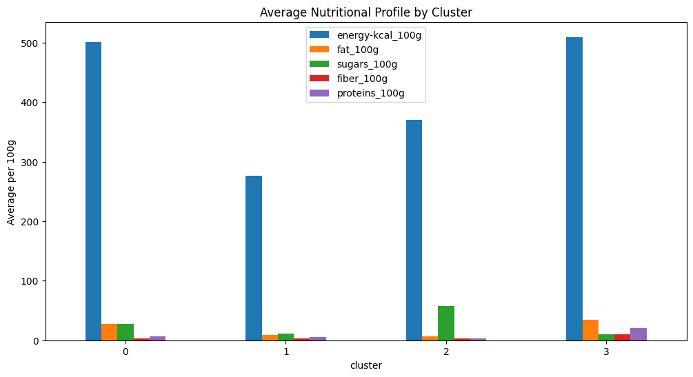

```python
import matplotlib.pyplot as plt

cluster_summary.plot(
    kind="bar",
    figsize=(12,6)
)

plt.title("Average Nutritional Profile by Cluster")
plt.ylabel("Average per 100g")
plt.xticks(rotation=0)

plt.show()
```

Evidence 1

NOS ranking: Protein Bars

Evidence 2

High-protein ingredient analysis: Soy Peanuts Whey

Evidence 3

Cluster 3 represents: High Protein High Fiber Low Sugar

Evidence 4

The Sugar vs Protein scatter plot showed a large concentration of products in low-protein regions and relatively fewer products in high-protein regions.

```python
%whos DataFrame
```

[output not shown]

```python
cluster_df.to_csv(
    "cluster_df.csv",
    index=False
)

nos_df.to_csv(
    "nos_df.csv"
)

category_summary.to_csv(
    "category_summary.csv"
)
```

```python
from collections import Counter

protein_keywords = [
    "whey",
    "soy",
    "soy protein",
    "pea protein",
    "pea",
    "peanut",
    "peanuts",
    "almond",
    "almonds",
    "cashew",
    "egg",
    "oats"
]

counter = Counter()

for text in opportunity_df["ingredients_text"].fillna("").str.lower():

    for ingredient in protein_keywords:

        if ingredient in text:
            counter[ingredient] += 1

ingredient_counts = (
    pd.Series(counter)
    .sort_values(ascending=False)
    .reset_index()
)

ingredient_counts.columns = [
    "ingredient",
    "count"
]

ingredient_counts.to_csv(
    "ingredient_counts.csv",
    index=False
)

ingredient_counts.head(10)
```

|  | ingredient | count |
| --- | --- | --- |
| 0 | soy | 4022 |
| 1 | pea | 3607 |
| 2 | peanut | 2420 |
| 3 | peanuts | 2036 |
| 4 | whey | 1688 |
| 5 | almond | 1541 |
| 6 | almonds | 1284 |
| 7 | cashew | 1131 |
| 8 | egg | 1059 |
| 9 | oats | 919 |